# Enhanced not Distant: Examining Independence in the Novels of Austen, Edgeworth, and Owenson

Paper for Digital Cultures, Big Data and Society

Sara J Kerr

February 2018

### Introduction

This document provides the code and results for the analysis conducted for the paper ‘Enhanced not Distant: Examining Independence in the Novels of Austen, Edgeworth, and Owenson’ presented at the ‘Digital Cultures, Big Data and Society’ conference on 15th and 16th February 2018.

This paper proposes a shift in focus from close and distant reading, and suggests instead considering the combined use of these methods as enhanced reading, which has the purpose of further improving the quality and extent of close readings of the texts through the use of digital methods. As a core part of this redefinition, is the importance of greater openness with regard to the texts, tools, and the parameters used. This provides the opportunity of making textual analysis a little more replicable, capitalising on the strengths of computational methods, allowing the researcher to repeat a particular analysis, and view the source of an interpretation.

### Raw and Weighted Frequencies

At the most straightforward level, computational techniques allow the examination of the frequency of words. The raw frequency is the actual count of a word in a text, whereas the relative frequency is the frequency normalised by representing it as a proportion of the text as a whole.

The Austen, Edgeworth, Owenson corpus was converted into a Document Term Matrix using the `tm` package. The DTM represents the raw frequencies of each word in the corpus by text.

```r
input.dir <- "AEO_corpus"
# Read the name of all .txt files
files <- dir(input.dir, "\\.txt")
# Create Volatile Corpus
docs <- VCorpus(DirSource(input.dir))
# Preprocess corpus
docs <- tm_map(docs, removePunctuation)   # Remove punctuation
docs <- tm_map(docs, removeNumbers)      # Remove numbers
docs <- tm_map(docs, tolower)   # Convert to lowercase
docs <- tm_map(docs, stripWhitespace)   # Strip whitespace
docs <- tm_map(docs, PlainTextDocument)
# Create formats needed for analysis
# Create a Document Term Matrix
dtm <- DocumentTermMatrix(docs)
rownames(dtm) <- files # Allocates text names to rows
# Convert DTM to matrix
m <- as.matrix(dtm)
```

Although raw frequencies can be interesting when examining a single text, if the purpose is to compare texts some form of normalisation needs to take place. For this paper term frequency-inverse document frequency (Tf-Idf) of each term will be used. This weighting metric is a statistical measure of how important a word is to a document in a corpus.

```r
corp_tfidf <- weightTfIdf(dtm)
corp_tfidf <- as.matrix(corp_tfidf)
corp_tfidf <- as.data.frame(corp_tfidf)
corp_tfidf$Text <- rownames(corp_tfidf) # Adds a column of text names
corp_tfidf$Author <- gsub("_.*","", corp_tfidf$Text) # adds a column of author names
corp_tf <- corp_tfidf %>%
         gather(key, Value, - Text, - Author)
colnames(corp_tf) <- c("Text", "Author", "Word", "Value")
```

The weightings of the focus terms *conduct*, *education* and *rank* can be viewed. The term *status* which was originally noted in the conference abstract was changed to *rank* as *status* only became associated with social class in 1820 (Historical Thesaurus), and only came to mean having or conferring social status in 1950.

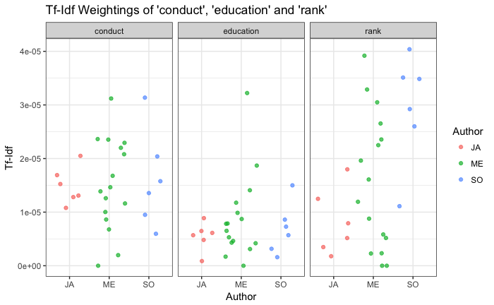

```r
corp_tf %>%
        filter(Word == "education" | Word == "rank" | Word == "conduct") %>%
        ggplot(aes(x = Author, y = Value, col = Author)) +
        geom_jitter(alpha = 0.7) +
        theme_bw() +
        theme() +
        ggtitle("Tf-Idf Weightings of 'conduct', 'education' and 'rank'") +
        labs(y = "Tf-Idf") +
        facet_grid(. ~ Word)
```

The texts in which the terms are most significant can be identified.

```r
corp_tf %>%
         filter(Author == "JA") %>%
         filter(Word == "education" | Word == "rank" | Word == "conduct") %>%
         group_by(Word, Text)
```

| Text | Author | Word | Value |
| --- | --- | --- | --- |
| JA_1811_SS.txt | JA | conduct | 2.049709e-05 |
| JA_1813_PP.txt | JA | conduct | 1.280943e-05 |
| JA_1814_MP.txt | JA | conduct | 1.690630e-05 |
| JA_1815_E.txt | JA | conduct | 1.079577e-05 |
| JA_1818_NA.txt | JA | conduct | 1.309263e-05 |
| JA_1818_P.txt | JA | conduct | 1.524586e-05 |
| JA_1811_SS.txt | JA | education | 5.693635e-06 |
| JA_1813_PP.txt | JA | education | 6.126249e-06 |
| JA_1814_MP.txt | JA | education | 8.875805e-06 |
| JA_1815_E.txt | JA | education | 6.477459e-06 |

[output cut: 8 more lines]

```r
corp_tf %>%
         filter(Author == "ME") %>%
         filter(Word == "education" | Word == "rank" | Word == "conduct") %>%
         group_by(Word, Text)
```

| Text | Author | Word | Value |
| --- | --- | --- | --- |
| ME_1800_CR.txt | ME | conduct | 1.973869e-06 |
| ME_1801_B.txt | ME | conduct | 2.363105e-05 |
| ME_1804_PT.txt | ME | conduct | 1.002845e-05 |
| ME_1805_MG.txt | ME | conduct | 3.119718e-05 |
| ME_1806_E.txt | ME | conduct | 2.200556e-05 |
| ME_1806_L.txt | ME | conduct | 2.352751e-05 |
| ME_1809_A.txt | ME | conduct | 2.080481e-05 |
| ME_1809_D.txt | ME | conduct | 0.000000e+00 |
| ME_1809_M.txt | ME | conduct | 1.678134e-05 |
| ME_1809_MF.txt | ME | conduct | 1.464425e-05 |

[output cut: 38 more lines]

```r
corp_tf %>%
         filter(Author == "SO") %>%
         filter(Word == "education" | Word == "rank" | Word == "conduct") %>%
         group_by(Word, Text)
```

| Text | Author | Word | Value |
| --- | --- | --- | --- |
| SO_1803_SC.txt | SO | conduct | 3.136617e-05 |
| SO_1806_NS.txt | SO | conduct | 2.039377e-05 |
| SO_1806_WG.txt | SO | conduct | 5.963713e-06 |
| SO_1811_M.txt | SO | conduct | 1.355892e-05 |
| SO_1814_OD.txt | SO | conduct | 1.577622e-05 |
| SO_1818_FM.txt | SO | conduct | 9.502075e-06 |
| SO_1803_SC.txt | SO | education | 1.500121e-05 |
| SO_1806_NS.txt | SO | education | 3.159598e-06 |
| SO_1806_WG.txt | SO | education | 7.288982e-06 |
| SO_1811_M.txt | SO | education | 1.595167e-06 |

[output cut: 8 more lines]

```r
NA
NA
```

It may not be a surprise that *Sense and Sensibility* has the highest relative frequency of Austen’s novels for the term *conduct*, or that *Mansfield Park* has the highest for *education*, or that Edgeworth’s *Absentee* has the highest relative frequency for *rank* but it shows how word frequency is linked to themes within the text.

### Collocations

The three focal terms for the study - education, rank, conduct - can be by considering the collocations. Collocations are calculated based on the raw frequency of the words and are read vertically. For this study I have only compared the collocations which are positioned one step away from the focus word. First we load the function:

```r
# Collocations
# Adapted from Stefan Th Gries - Quantitative Corpus Linguistics with R
# Collocation function
# Variables
# input - corpus: path to file in speech marks
# word: in speech marks
# span: number of context
# output: path to file in speech marks - output file saved to folder
collocation <- function(corpus, word, num, output) {
        corpus_x <- tolower(scan(file = corpus, what = "char",
                                 sep = "\n", quiet = T))
        search_word <- paste0("\\b", word, "\\b")
        span <- num;
        span <- (-span:span)
        output_x <- output

        cleaned <- strsplit(corpus_x, "\\W")
        cleaned <- unlist(cleaned)
        cleaned <- cleaned[which(cleaned != "")]

        pos_match <- grep(search_word, cleaned, perl = T)

        results <- list()
        for(i in 1:length(span)) {
                collocate_pos <- pos_match + span[i]
                collocates <- cleaned[collocate_pos]
                sorted_collocates <- sort(table(collocates), decreasing = T)
                results[[i]] <- sorted_collocates
        }

        lengths <- sapply(results, length)

        cat(paste(rep(c("Word_", "Frequency_"), length(span)),
                  rep(span, each = 2), sep = ""),"\n", sep = ",", file = output)

        for(k in 1:max(lengths)) {
                output_string <- paste(names(sapply(results, "[", k)),
                                       sapply(results, "[", k), sep = ",")
                output_string2 <- gsub("NA\tNA", ",", output_string, perl = T)
                cat(output_string2, "\n", sep = ",", file = output, append = T)
        }
}
# To run
# collocation("Combined_Texts/ja.txt", "power", 2, "ja_coll_power.csv")
```

Then we will run the function on each of the three corpora.

```r
collocation("Combined_Texts/ja.txt", "education", 1, "Collocation/ja_coll_ed.csv")
collocation("Combined_Texts/me.txt", "education", 1, "Collocation/me_coll_ed.csv")
collocation("Combined_Texts/so.txt", "education", 1, "Collocation/so_coll_ed.csv")
ja_ed <- read.csv("Collocation/ja_coll_ed.csv")
ja_ed <- ja_ed[, -7]
head(ja_ed)
```

|  | Word_.1 | Frequency_.1 | Word_0 | Frequency_0 | Word_1 | Frequency_1 |
| --- | --- | --- | --- | --- | --- | --- |
| 1 | of | 7 | education | 65 | and | 14 |
| 2 | an | 5 | NA | NA | had | 6 |
| 3 | her | 5 | NA | NA | of | 3 |
| 4 | the | 5 | NA | NA | to | 3 |
| 5 | and | 4 | NA | NA | from | 2 |
| 6 | as | 2 | NA | NA | he | 2 |

```r
me_ed <- read.csv("Collocation/me_coll_ed.csv")
me_ed <- me_ed[, -7]
head(me_ed)
```

|  | Word_.1 | Frequency_.1 | Word_0 | Frequency_0 | Word_1 | Frequency_1 |
| --- | --- | --- | --- | --- | --- | --- |
| 1 | of | 25 | education | 164 | and | 22 |
| 2 | the | 21 | NA | NA | of | 17 |
| 3 | his | 11 | NA | NA | which | 9 |
| 4 | and | 10 | NA | NA | as | 6 |
| 5 | her | 10 | NA | NA | but | 5 |
| 6 | an | 7 | NA | NA | the | 5 |

```r
so_ed <- read.csv("Collocation/so_coll_ed.csv")
so_ed <- so_ed[, -7]
head(so_ed)
```

|  | Word_.1 | Frequency_.1 | Word_0 | Frequency_0 | Word_1 | Frequency_1 |
| --- | --- | --- | --- | --- | --- | --- |
| 1 | of | 14 | education | 68 | and | 12 |
| 2 | and | 8 | NA | NA | had | 10 |
| 3 | the | 7 | NA | NA | of | 6 |
| 4 | her | 3 | NA | NA | the | 4 |
| 5 | that | 3 | NA | NA | which | 3 |
| 6 | to | 3 | NA | NA | at | 2 |

```r
collocation("Combined_Texts/ja.txt", "rank", 1, "Collocation/ja_coll_ra.csv")
collocation("Combined_Texts/me.txt", "rank", 1, "Collocation/me_coll_ra.csv")
collocation("Combined_Texts/so.txt", "rank", 1, "Collocation/so_coll_ra.csv")
ja_ra <- read.csv("Collocation/ja_coll_ra.csv")
ja_ra <- ja_ra[, -7]
head(ja_ra)
```

|  | Word_.1 | Frequency_.1 | Word_0 | Frequency_0 | Word_1 | Frequency_1 |
| --- | --- | --- | --- | --- | --- | --- |
| 1 | of | 9 | rank | 42 | and | 10 |
| 2 | the | 4 | NA | NA | of | 7 |
| 3 | his | 3 | NA | NA | as | 3 |
| 4 | for | 2 | NA | NA | in | 3 |
| 5 | her | 2 | NA | NA | she | 2 |
| 6 | high | 2 | NA | NA | below | 1 |

```r
me_ra <- read.csv("Collocation/me_coll_ra.csv")
me_ra <- me_ra[, -7]
head(me_ra)
```

|  | Word_.1 | Frequency_.1 | Word_0 | Frequency_0 | Word_1 | Frequency_1 |
| --- | --- | --- | --- | --- | --- | --- |
| 1 | of | 39 | rank | 171 | and | 53 |
| 2 | and | 14 | NA | NA | of | 26 |
| 3 | the | 14 | NA | NA | in | 14 |
| 4 | high | 9 | NA | NA | or | 6 |
| 5 | certain | 8 | NA | NA | to | 4 |
| 6 | same | 7 | NA | NA | who | 4 |

```r
so_ra <- read.csv("Collocation/so_coll_ra.csv")
so_ra <- so_ra[, -7]
head(so_ra)
```

|  | Word_.1 | Frequency_.1 | Word_0 | Frequency_0 | Word_1 | Frequency_1 |
| --- | --- | --- | --- | --- | --- | --- |
| 1 | of | 32 | rank | 190 | and | 42 |
| 2 | the | 17 | NA | NA | in | 18 |
| 3 | and | 10 | NA | NA | of | 13 |
| 4 | her | 7 | NA | NA | or | 7 |
| 5 | his | 7 | NA | NA | but | 6 |
| 6 | to | 6 | NA | NA | to | 6 |

```r
collocation("Combined_Texts/ja.txt", "conduct", 1, "Collocation/ja_coll_co.csv")
collocation("Combined_Texts/me.txt", "conduct", 1, "Collocation/me_coll_co.csv")
collocation("Combined_Texts/so.txt", "conduct", 1, "Collocation/so_coll_co.csv")
ja_co <- read.csv("Collocation/ja_coll_co.csv")
ja_co <- ja_co[, -7]
head(ja_co)
```

|  | Word_.1 | Frequency_.1 | Word_0 | Frequency_0 | Word_1 | Frequency_1 |
| --- | --- | --- | --- | --- | --- | --- |
| 1 | his | 23 | conduct | 160 | and | 17 |
| 2 | s | 21 | NA | NA | in | 10 |
| 3 | of | 17 | NA | NA | of | 10 |
| 4 | her | 15 | NA | NA | i | 5 |
| 5 | my | 9 | NA | NA | which | 5 |
| 6 | own | 9 | NA | NA | as | 4 |

```r
me_co <- read.csv("Collocation/me_coll_co.csv")
me_co <- me_co[, -7]
head(me_co)
```

|  | Word_.1 | Frequency_.1 | Word_0 | Frequency_0 | Word_1 | Frequency_1 |
| --- | --- | --- | --- | --- | --- | --- |
| 1 | s | 36 | conduct | 313 | and | 35 |
| 2 | her | 35 | NA | NA | of | 28 |
| 3 | his | 31 | NA | NA | to | 17 |
| 4 | my | 19 | NA | NA | towards | 17 |
| 5 | the | 17 | NA | NA | the | 11 |
| 6 | good | 12 | NA | NA | i | 9 |

```r
so_co <- read.csv("Collocation/so_coll_co.csv")
so_co <- so_co[, -7]
head(so_co)
```

|  | Word_.1 | Frequency_.1 | Word_0 | Frequency_0 | Word_1 | Frequency_1 |
| --- | --- | --- | --- | --- | --- | --- |
| 1 | the | 24 | conduct | 178 | of | 29 |
| 2 | her | 19 | NA | NA | and | 18 |
| 3 | my | 14 | NA | NA | in | 7 |
| 4 | his | 12 | NA | NA | which | 7 |
| 5 | of | 11 | NA | NA | you | 7 |
| 6 | your | 10 | NA | NA | the | 6 |

The collocations reveal subtle differences between the author’s approaches to these key terms, as well as some broader insights into their attitudes.

However, basing a thematic analysis on results for a single term may be limiting and exclude areas worth of further investigation.

### Creating A Lexicon

As a starting point for further analysis I wanted to create a lexicon of terms which were associated with independence, and where possible to consider the meanings and connotations of independence during this period. 187 texts from the first two periods, 1710–1780 and 1780–1850, of CLMET3.1, totalling just over 22 million words, were selected and a word embedding model, using the `wordVectors` package, was created with 300 dimensions and a window of 12 words. CLMET3.1 is available free on request from the CLMET website.

```r
prep_word2vec("plain", "Clmet_processed_period_1_2.txt", lowercase = T)

clmet <- train_word2vec("Clmet_processed_period_1_2.txt",
                        output = "Bin_files/Clmet_model_period_1_2.bin", threads = 1,
                        vectors = 300, window = 12)
```

The model created is available in this GitHub repository.  
The created model is read into R and vector addition was used to identify the terms of interest. For this study the terms closest to `"independence" + "education"`, `"independence" + "conduct" + "propriety"`, and `"independence" + "rank"`.

```r
clmet <- read.vectors("Bin_files/Clmet_model_period_1_2.bin")
```

```r
education <- closest_to(clmet, ~  "independence" + "education", n = 500)
education <- education$word
conduct <- closest_to(clmet, ~ "independence" + "conduct" + "propriety", n =  500)
conduct <- conduct$word
rank <- closest_to(clmet, ~ "independence" + "rank", n = 500)
rank <- rank$word
```

The terms can be combined and the top words for each term can be viewed:

```r
lexicon_erc <- as.data.frame(cbind(education, rank, conduct))
colnames(lexicon_erc) <- c("Education", "Rank", "Conduct")
head(lexicon_erc)
```

|  | Education | Rank | Conduct |
| --- | --- | --- | --- |
| 1 | education | independence | propriety |
| 2 | independence | rank | conduct |
| 3 | freedom | dignity | independence |
| 4 | habits | station | prudence |
| 5 | society | reputation | freedom |
| 6 | learning | freedom | character |

The 500 terms in the lexicon_erc were then filtered to remove any which were not present in the AEO corpus and the top 350 terms saved as the `lexicon_in_aeo`. The top 100 words which did not appear in the AEO corpus were saved as `lexicon_ex`.

```r
# Identify independence terms which appear in the AEO texts
words <- colnames(m)
rank_terms <- rank[which(rank %in% words == T)]
education_terms <- education[which(education %in% words == T)]
conduct_terms <- conduct[which(conduct %in% words == T)]
# words not in AEO Corpus
ex_rank_terms <- rank[which(rank %in% words == F)]
ex_education_terms <- education[which(education %in% words == F)]
ex_conduct_terms <- conduct[which(conduct %in% words == F)]
# Create lexicon with top 350 filtered terms for each category
lexicon_in_aeo <- as.data.frame(cbind(education_terms[1:350], rank_terms[1:350],
                        conduct_terms[1:350]))
colnames(lexicon_in_aeo) <- c("Education", "Rank", "Conduct")
# Words not appearing in AEO - top 100
lexicon_ex <- as.data.frame(cbind(ex_education_terms[1:100], ex_rank_terms[1:100],
                    ex_conduct_terms[1:100]))
colnames(lexicon_ex) <- c("Education", "Rank", "Conduct")
```

The top terms in each of these data frames can be viewed.

```r
head(lexicon_in_aeo)
```

|  | Education | Rank | Conduct |
| --- | --- | --- | --- |
| 1 | education | independence | propriety |
| 2 | independence | rank | conduct |
| 3 | freedom | dignity | independence |
| 4 | habits | station | prudence |
| 5 | society | reputation | freedom |
| 6 | learning | freedom | character |

```r
head(lexicon_ex)
```

|  | Education | Rank | Conduct |
| --- | --- | --- | --- |
| 1 | ampler | aggrandisement | animadverting |
| 2 | deprave | independency | comprehensiveness |
| 3 | unblameable | descendents | unswerving |
| 4 | aggrandizing | burgher | humanizing |
| 5 | instill | insular | overstep |
| 6 | unlearn | weening | culpability |

Comparing the terms which do not appear in the AEO corpus we see a number of terms which are infrequent in modern usage. This may be due to the broader scope of the CLMET3.1 corpus in terms of date, or text type.

Examining the top terms in the `lexicon_in_aeo` data frame reveals that a number of terms are shared, for example *freedom*. To try to make the focus of each set of terms as close to each sub-theme as possible, unique terms are extracted, as are the top 120 terms which appear in more than one category.

```r
# Calculating unique terms for education, rank and conduct
ed <- as.character(lexicon_in_aeo[,1])
ra <- as.character(lexicon_in_aeo[,2])
con <- as.character(lexicon_in_aeo[,3])
words <- c(ra, con)
ed_terms <- ed[which(ed %in% words != T)]
words <- c(ed, con)
ra_terms <- ra[which(ra %in% words != T)]
words <- c(ed, ra)
con_terms <- con[which(con %in% words != T)]
# Identify terms which appear in one or more category
words2 <- c(ed_terms, ra_terms, con_terms)
edracon <- c(ed, ra, con)
generic_terms <- edracon[which(edracon %in% words2 != T)]
# Combine unique terms
lex_erc_unique <- as.data.frame(cbind(ed_terms[1:120], ra_terms[1:120], con_terms[1:120],
                        generic_terms[1:120]))
colnames(lex_erc_unique) <- c("Education", "Rank", "Conduct", "Generic")
# View the top 10 terms
lex_erc_unique[1:10, ]
```

|  | Education | Rank | Conduct | Generic |
| --- | --- | --- | --- | --- |
| 1 | learning | exalted | propriety | education |
| 2 | institutions | affluence | justice | independence |
| 3 | parents | honors | judgment | freedom |
| 4 | improvement | preeminence | regard | habits |
| 5 | instruction | greatness | rectitude | society |
| 6 | acquirement | nobility | generosity | independent |
| 7 | educated | ranks | delicacy | acquired |
| 8 | discipline | beauty | approbation | reputation |
| 9 | establishment | glory | benevolence | talents |
| 10 | retrenchments | possess | candour | literature |

### Exploring Frequencies - Thematic Terms

The lexicon created earlier is used to extract the terms of interest with their relative frequency.

```r
education_w <- as.character(lex_erc_unique[,1])
rank_w <- as.character(lex_erc_unique[,2])
conduct_w <- as.character(lex_erc_unique[,3])
generic_w <- as.character(lex_erc_unique[,4])
# Create sub-theme results
corp_education <- subset.data.frame(corp_tfidf, select = education_w)
corp_education$Text <- rownames(corp_education)
corp_education$Theme <- rep("Education", times = nrow(corp_education))
corp_rank <- subset.data.frame(corp_tfidf, select = rank_w)
corp_rank$Text <- rownames(corp_rank)
corp_rank$Theme <- rep("Rank", times = nrow(corp_rank))
corp_conduct <- subset.data.frame(corp_tfidf, select = conduct_w)
corp_conduct$Text <- rownames(corp_conduct)
corp_conduct$Theme <- rep("Conduct", times = nrow(corp_conduct))
corp_generic <- subset.data.frame(corp_tfidf, select = generic_w)
corp_generic$Text <- rownames(corp_generic)
corp_generic$Theme <- rep("Generic", times = nrow(corp_generic))
corp_join <- full_join(corp_rank, corp_education, by = c("Text", "Theme")) %>%
              full_join(corp_conduct, by = c("Text", "Theme")) %>%
              full_join(corp_generic, by = c("Text", "Theme"))
# combine the sub-themes
corp_tf_aeo <- corp_join %>%
        gather(key, Value, - Text, -Theme)
# remove NA rows
corp_tf_aeo <- filter(corp_tf_aeo, Value != "NA")
colnames(corp_tf_aeo) <- c("Text", "Theme", "Word", "Value")
# Extract the Author name from the Text variable
corp_tf_aeo$Author <- gsub("_.*","", corp_tf_aeo$Text)
# View the results
head(corp_tf_aeo)
```

|  | Text | Theme | Word | Value | Author |
| --- | --- | --- | --- | --- | --- |
| 1 | JA_1811_SS.txt | Rank | exalted | 0 | JA |
| 2 | JA_1813_PP.txt | Rank | exalted | 0 | JA |
| 3 | JA_1814_MP.txt | Rank | exalted | 0 | JA |
| 4 | JA_1815_E.txt | Rank | exalted | 0 | JA |
| 5 | JA_1818_NA.txt | Rank | exalted | 0 | JA |
| 6 | JA_1818_P.txt | Rank | exalted | 0 | JA |

The Tf-Idf weightings of the terms can now be plotted.

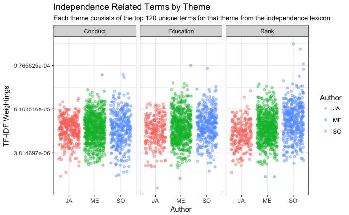

```r
pt <- corp_tf_aeo %>%
        filter(Value > 0, Theme != "Generic") %>%
        ggplot(aes(x = Author, y = Value, col = Author)) +
        geom_jitter(alpha = 0.4) +
        scale_y_continuous(trans='log2') +
        theme_bw() +
        theme() +
        ggtitle("Independence Related Terms by Theme") +
        labs(y = "TF-IDF Weightings",
             subtitle = "Each theme consists of the top 120 unique terms for that theme from the independence lexicon") +
        facet_grid(. ~ Theme)
pt
```

### Changes Over Time

To examine how an author’s use of words varies over time the date of each text is added to the data.

```r
corp_tf_aeo$Year <- gsub("[^0-9]", "", corp_tf_aeo$Text)
```

However, this can be misleading if there is more than one text published in a single year. Therefore, it is more revealing to plot by individual text, especially as the text names include the date of the text. The terms can now be plotted:

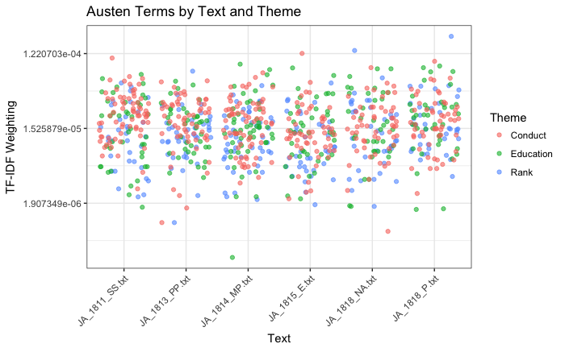

```r
corp_tf_aeo %>%
        filter(Value > 0 & Author == "JA" & Theme != "Generic") %>%
        ggplot(aes(x = Text, y = Value, col = Theme)) +
        geom_jitter(alpha = 0.6) +
        scale_y_continuous(trans='log2') +
        theme_bw() +
        theme(axis.text.x=element_text(angle=45, hjust = 1)) +
        ggtitle("Austen Terms by Text and Theme") +
        labs(y = "TF-IDF Weighting")
```

```r
NA
```

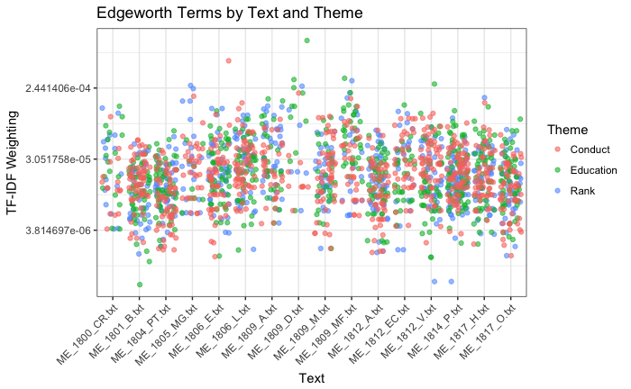

```r
corp_tf_aeo %>%
        filter(Value > 0 & Author == "ME" & Theme != "Generic") %>%
        ggplot(aes(x = Text, y = Value, col = Theme)) +
        geom_jitter(alpha = 0.6) +
        scale_y_continuous(trans='log2') +
        theme_bw() +
        theme(axis.text.x=element_text(angle=45, hjust = 1)) +
        ggtitle("Edgeworth Terms by Text and Theme") +
        labs(y = "TF-IDF Weighting")
```

```r
NA
```

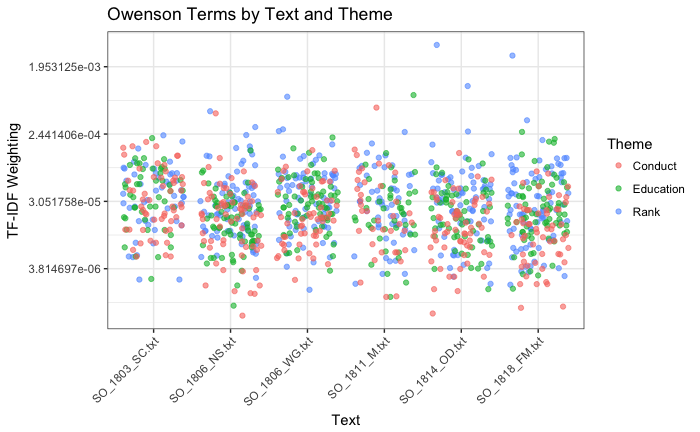

```r
corp_tf_aeo %>%
        filter(Value > 0 & Author == "SO" & Theme != "Generic") %>%
        ggplot(aes(x = Text, y = Value, col = Theme)) +
        geom_jitter(alpha = 0.6) +
        scale_y_continuous(trans='log2') +
        theme_bw() +
        theme(axis.text.x=element_text(angle=45, hjust = 1)) +
        ggtitle("Owenson Terms by Text and Theme") +
        labs(y = "TF-IDF Weighting")
```

```r
NA
```

These plots allow us to consider the themes across the author’s corpus. The data can be examined in closer detail.

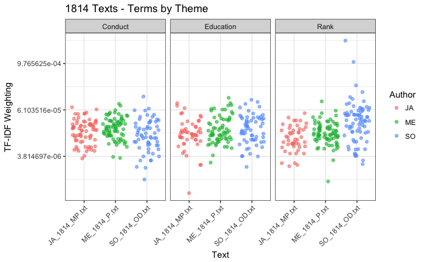

```r
corp_tf_aeo %>%
        filter(Value > 0 & Theme != "Generic") %>%
        filter(Text == "JA_1814_MP.txt" | Text == "ME_1814_P.txt" | Text == "SO_1814_OD.txt") %>%
        ggplot(aes(x = Text, y = Value, col = Author)) +
        #geom_point(alpha = 0.6) +
        geom_jitter(alpha = 0.6) +
        scale_y_continuous(trans='log2') +
        theme_bw() +
        theme(axis.text.x=element_text(angle=45, hjust = 1)) +
        ggtitle("1814 Texts - Terms by Theme") +
        labs(y = "TF-IDF Weighting") +
        facet_grid(. ~ Theme)
```

```r
NA
```

The highest weighted terms can be extracted from the larger set and then be examined by author.

```r
high_tf <-corp_tf_aeo %>% filter(Value > 6.103516e-05) # Value taken from plot Terms by Theme
ja_high_tf <- high_tf %>% filter(Author == "JA") %>%
                          arrange(desc(Value))
head(ja_high_tf, n = 10)
```

|  | Text | Theme | Word | Value | Author | Year |
| --- | --- | --- | --- | --- | --- | --- |
| 1 | JA_1813_PP.txt | Generic | connections | 0.0004484997 | JA | 1813 |
| 2 | JA_1818_P.txt | Generic | usefulness | 0.0002464093 | JA | 1818 |
| 3 | JA_1818_P.txt | Rank | precedence | 0.0001971274 | JA | 1818 |
| 4 | JA_1811_SS.txt | Generic | connections | 0.0001348562 | JA | 1811 |
| 5 | JA_1818_NA.txt | Rank | wealthy | 0.0001330871 | JA | 1818 |
| 6 | JA_1814_MP.txt | Generic | usefulness | 0.0001297918 | JA | 1814 |
| 7 | JA_1815_E.txt | Conduct | unreserve | 0.0001227371 | JA | 1815 |
| 8 | JA_1815_E.txt | Generic | disparity | 0.0001152263 | JA | 1815 |
| 9 | JA_1811_SS.txt | Conduct | unreserve | 0.0001078850 | JA | 1811 |
| 10 | JA_1811_SS.txt | Generic | ineligible | 0.0001043365 | JA | 1811 |

```r
NA
```

```r
me_high_tf <- high_tf %>% filter(Author == "ME") %>%
                          arrange(desc(Value))
head(me_high_tf, n = 10)
```

|  | Text | Theme | Word | Value | Author | Year |
| --- | --- | --- | --- | --- | --- | --- |
| 1 | ME_1809_D.txt | Education | calculator | 0.0009817831 | ME | 1809 |
| 2 | ME_1806_E.txt | Conduct | ment | 0.0005420596 | ME | 1806 |
| 3 | ME_1814_P.txt | Generic | patronage | 0.0004007973 | ME | 1814 |
| 4 | ME_1809_MF.txt | Education | school | 0.0003251715 | ME | 1809 |
| 5 | ME_1809_D.txt | Education | political | 0.0003129363 | ME | 1809 |
| 6 | ME_1809_MF.txt | Rank | servile | 0.0003026719 | ME | 1809 |
| 7 | ME_1809_MF.txt | Generic | industry | 0.0002791113 | ME | 1809 |
| 8 | ME_1812_V.txt | Education | political | 0.0002750027 | ME | 1812 |
| 9 | ME_1805_MG.txt | Rank | sovereign | 0.0002632692 | ME | 1805 |
| 10 | ME_1809_D.txt | Rank | enjoyments | 0.0002578649 | ME | 1809 |

```r
so_high_tf <- high_tf %>% filter(Author == "SO") %>%
                          arrange(desc(Value))
head(so_high_tf, n = 10)
```

|  | Text | Theme | Word | Value | Author | Year |
| --- | --- | --- | --- | --- | --- | --- |
| 1 | SO_1814_OD.txt | Rank | honor | 0.0038272525 | SO | 1814 |
| 2 | SO_1818_FM.txt | Rank | honor | 0.0027547435 | SO | 1818 |
| 3 | SO_1811_M.txt | Generic | religion | 0.0014534832 | SO | 1811 |
| 4 | SO_1814_OD.txt | Rank | favor | 0.0010754358 | SO | 1814 |
| 5 | SO_1811_M.txt | Education | religious | 0.0008139506 | SO | 1811 |
| 6 | SO_1806_WG.txt | Rank | milesian | 0.0007732440 | SO | 1806 |
| 7 | SO_1811_M.txt | Conduct | zeal | 0.0005527687 | SO | 1811 |
| 8 | SO_1806_NS.txt | Rank | splendor | 0.0004939533 | SO | 1806 |
| 9 | SO_1806_NS.txt | Conduct | ment | 0.0004626252 | SO | 1806 |
| 10 | SO_1818_FM.txt | Rank | honors | 0.0003734970 | SO | 1818 |

### More Collocations

```r
collocation("Combined_Texts/ja.txt", "power", 1, "Collocation/ja_coll_power.csv")
collocation("Combined_Texts/ja.txt", "country", 1, "Collocation/ja_coll_country.csv")
collocation("Combined_Texts/ja.txt", "fortune", 1, "Collocation/ja_coll_fortune.csv")
collocation("Combined_Texts/ja.txt", "impropriety", 1, "Collocation/ja_coll_impropriety.csv")
collocation("Combined_Texts/me.txt", "power", 1, "Collocation/me_coll_power.csv")
collocation("Combined_Texts/me.txt", "country", 1, "Collocation/me_coll_country.csv")
collocation("Combined_Texts/me.txt", "fortune", 1, "Collocation/me_coll_fortune.csv")
collocation("Combined_Texts/me.txt", "impropriety", 1, "Collocation/me_coll_impropriety.csv")
collocation("Combined_Texts/so.txt", "power", 1, "Collocation/so_coll_power.csv")
collocation("Combined_Texts/so.txt", "country", 1, "Collocation/so_coll_country.csv")
collocation("Combined_Texts/so.txt", "fortune", 1, "Collocation/so_coll_fortune.csv")
collocation("Combined_Texts/so.txt", "impropriety", 1, "Collocation/so_coll_impropriety.csv")
ja_impropriety <- read.csv("Collocation/ja_coll_impropriety.csv")
ja_impropriety <- ja_impropriety[, -7]
head(ja_impropriety)
```

|  | Word_.1 | Frequency_.1 | Word_0 | Frequency_0 | Word_1 | Frequency_1 |
| --- | --- | --- | --- | --- | --- | --- |
| 1 | the | 7 | impropriety | 20 | of | 9 |
| 2 | or | 2 | NA | NA | in | 5 |
| 3 | _is_ | 1 | NA | NA | is | 1 |
| 4 | and | 1 | NA | NA | it | 1 |
| 5 | beyond | 1 | NA | NA | nobody | 1 |
| 6 | conduct | 1 | NA | NA | oh | 1 |

```r
me_impropriety<- read.csv("Collocation/me_coll_impropriety.csv")
me_impropriety <- me_impropriety[, -7]
head(me_impropriety)
```

|  | Word_.1 | Frequency_.1 | Word_0 | Frequency_0 | Word_1 | Frequency_1 |
| --- | --- | --- | --- | --- | --- | --- |
| 1 | any | 3 | impropriety | 14 | of | 5 |
| 2 | no | 3 | NA | NA | in | 4 |
| 3 | the | 3 | NA | NA | and | 1 |
| 4 | or | 2 | NA | NA | could | 1 |
| 5 | an | 1 | NA | NA | not | 1 |
| 6 | great | 1 | NA | NA | on | 1 |

```r
so_impropriety<- read.csv("Collocation/so_coll_impropriety.csv")
so_impropriety <- so_impropriety[, -7]
head(so_impropriety)
```

|  | Word_.1 | Frequency_.1 | Word_0 | Frequency_0 | Word_1 | Frequency_1 |
| --- | --- | --- | --- | --- | --- | --- |
| 1 | the | 3 | impropriety | 6 | of | 4 |
| 2 | any | 1 | NA | NA | apply | 1 |
| 3 | some | 1 | NA | NA | she | 1 |
| 4 | unguarded | 1 | NA | NA | NA | NA |

### Word Embedding Models

Although the terms related to the three themes have been explored, it is also interesting to apply a word embedding model to each author corpus to identify the terms that the author associates with education, rank and conduct.

```r
ja <- read.vectors("Bin_files/ja_ucd.bin")
```

```r
me <- read.vectors("Bin_files/me_ucd.bin")
```

```r
so <- read.vectors("Bin_files/so_ucd.bin")
```

The word embedding analysis is carried out using a custom function which creates a number of outputs, allowing the results to be examined at a later date.

```r
# w2v_analysis2 analyses a chosen term in a vector space model
# The function takes 6 arguments:
# vsm - a vector space model
# words - a character vector of focus words
# seed - an integer
# path - the path to the folder you want files saved to
# ref_name - the reference name for the exported files
# num - the number of nearest words you wish to examine
# The function will create a vector which is the average of the words input and
# will output a wordlist of the n nearest words, a csv of the words and their
# positions, and a plot of the 2D reduction of the vector space
# model using the Barnes-Hut implementation of t-SNE. The points for each word
# are marked in red so the labels can be moved by ggrepel for ease of reading.
# An HTML network graph for the chosen word will also be created
# set.seed is used to ensure replicability
w2v_analysis2 <- function(vsm, words, seed, path, ref_name, num) {
        # Set the seed
        if (!missing(seed))
                set.seed(seed)

        # Identify the nearest 10 words to the average vector of search terms
        ten <- closest_to(vsm, vsm[[words]])

        # Identify the nearest n words to the average vector of search terms and
        # save as a .txt file
        main <- nearest_to(vsm, vsm[[words]], num)
        wordlist <- names(main)
        filepath <- paste0(path, ref_name)
        write(wordlist, paste0(filepath, ".txt"))


        # Create a subset vector space model
        new_model <- vsm[[wordlist, average = F]]

        # Run Rtsne to reduce new VSM to 2D (Barnes-Hut)
        reduction <- Rtsne(as.matrix(new_model), dims = 2, initial_dims = 50,
                           perplexity = 30, theta = 0.5, check_duplicates = F,
                           pca = F, max_iter = 1000, verbose = F,
                           is_distance = F, Y_init = NULL)

        # Extract Y (positions for plot) as a dataframe and add row names
        df <- as.data.frame(reduction$Y)
        rows <- rownames(new_model)
        rownames(df) <- rows

        # Save dataframe as .csv file
        write.csv(df, paste0(filepath, ".csv"))

        # Create t-SNE plot and save as jpeg
        ggplot(df) +
                geom_point(aes(x = V1, y = V2), color = "red") +
                geom_text_repel(aes(x = V1, y = V2, label = rownames(df),
                                    size = 8)) +
                xlab("Dimension 1") +
                ylab("Dimension 2 ") +
                theme_bw(base_size = 16) +
                theme(legend.position = "none") +
                ggtitle(paste0("2D reduction of VSM ", ref_name, " using t_SNE"))

        ggsave(paste0(ref_name, ".jpeg"), path = path, width = 24,
               height = 18, dpi = 100)

        # Create a network plot of the words
        sim <- cosineSimilarity(new_model, new_model) %>% round(2)
        # convert those below threshold to 0
        sim[sim < max(sim)/2] <- 0
        g <- graph_from_incidence_matrix(sim)

        #g3 <- make_ego_graph(graph = g, order = 1, nodes = V(g)[name == word],
        #             mode = "out", mindist = 0)
        # Create a graph object
        # edges <- get.edgelist(g3[[1]])
        # edges <- as.data.frame(edges)
        #
        # nodes <- as.data.frame(unique(edges[, 2])) # Removes duplicate words
        #
        # net <- graph_from_data_frame(d = edges, vertices = nodes, directed = T)
        #
        # net <- simplify(net, remove.multiple = T, remove.loops = T) # removes loops
        # #net # This prints a section of the vertex names and links
        #
        # # This acts as a test that the graph will plot (lables have been removed)
        # #plot(net, edge.arrow.size = .4, vertex.label = NA)
        #
        #
        # # Create visNetwork version of graph
        #
        # data <- toVisNetworkData(net)
        # visNetwork(nodes = data$nodes, edges = data$edges, main = "Network of Terms") %>%
        #         visOptions(highlightNearest = T) %>%
        #         visSave(paste0(ref_name, ".html"))

        # Larger plot - Takes a long time show
        edges <- get.edgelist(g)
        # Name columns
         colnames(edges) <- c("from", "to")
         g2 <- graph(edges = edges)
         g2 <- simplify(g2) # removes loops
     # Community detection based on greedy optimization of modularity
        # cfg <- cluster_fast_greedy(as.undirected(g2))
        # V(g2)$community <- cfg$membership
        # pal2 <- rainbow(33, alpha = 0.7)
        # V(g2)$color <- pal2[V(g2)$community]
        data <- toVisNetworkData(g2)
         visNetwork(nodes = data$nodes, edges = data$edges, main = "Network of Terms") %>%
                visOptions(highlightNearest = T) %>%
                visSave(paste0(ref_name, ".html"))


        #new_list <- list("Ten closest" = ten, "Status" = "Analysis Complete")
        return(ten) # replace with new_list if running as stand alone.

}
```

The function can now be applied to the individual text corpora.

```r
w2v_analysis2(ja, c("independence", "education"), 42, "W2V", "ja_ed", 300)
```

| word | similarity to vsm[[words]] |
| --- | --- |
| education | 0.8449396 |
| independence | 0.8322372 |
| illiterate | 0.6543468 |
| decorum | 0.6452732 |
| affluence | 0.6429039 |
| liberality | 0.6412369 |
| foreign | 0.6372045 |
| respectability | 0.6258070 |
| privilege | 0.6203424 |
| nicety | 0.6148619 |

```r
w2v_analysis2(ja, c("independence", "conduct", "propriety"), 42, "W2V", "ja_con", 300)
```

| word | similarity to vsm[[words]] |
| --- | --- |
| propriety | 0.7644699 |
| independence | 0.7480361 |
| conduct | 0.7204257 |
| arrogance | 0.7146520 |
| decorum | 0.6949807 |
| confide | 0.6767660 |
| individual | 0.6625409 |
| obstinacy | 0.6622826 |
| atone | 0.6594536 |
| inferiority | 0.6591436 |

```r
w2v_analysis2(ja, c("independence", "rank"), 42, "W2V", "ja_ra", 300)
```

| word | similarity to vsm[[words]] |
| --- | --- |
| rank | 0.8373875 |
| independence | 0.8345598 |
| inferiority | 0.6439992 |
| model | 0.6436069 |
| decorum | 0.6345736 |
| foreign | 0.6274890 |
| respectability | 0.6268024 |
| display | 0.6238370 |
| illiterate | 0.6100427 |
| liberality | 0.6099524 |

```r
w2v_analysis2(me, c("independence", "education"), 42, "W2V", "me_ed", 300)
```

| word | similarity to vsm[[words]] |
| --- | --- |
| independence | 0.8304337 |
| education | 0.8033509 |
| precepts | 0.5826519 |
| respectability | 0.5729094 |
| subordination | 0.5602049 |
| greatness | 0.5496903 |
| habits | 0.5437650 |
| diminishing | 0.5423602 |
| fruits | 0.5391290 |
| understandings | 0.5312719 |

```r
w2v_analysis2(me, c("independence", "conduct", "propriety"), 42, "W2V", "me_con", 300)
```

| word | similarity to vsm[[words]] |
| --- | --- |
| independence | 0.7840707 |
| propriety | 0.7612972 |
| conduct | 0.6842888 |
| diminishing | 0.6202232 |
| greatness | 0.6163460 |
| compatible | 0.5915785 |
| acrimony | 0.5883454 |
| rudeness | 0.5765445 |
| definition | 0.5749813 |
| biassed | 0.5732127 |

```r
w2v_analysis2(me, c("independence", "rank"), 42, "W2V", "me_ra", 300)
```

| word | similarity to vsm[[words]] |
| --- | --- |
| rank | 0.8224599 |
| independence | 0.7891450 |
| respectability | 0.6387306 |
| combine | 0.5662938 |
| subordination | 0.5657170 |
| greatness | 0.5591790 |
| fashion | 0.5525931 |
| station | 0.5509154 |
| connexions | 0.5458156 |
| commerce | 0.5448092 |

```r
w2v_analysis2(so, c("independence", "education"), 42, "W2V", "so_ed", 300)
```

| word | similarity to vsm[[words]] |
| --- | --- |
| education | 0.8788888 |
| independence | 0.8286950 |
| acquirements | 0.6614207 |
| industry | 0.6554561 |
| distinctions | 0.6488139 |
| tedium | 0.6440423 |
| affluence | 0.6432243 |
| overbearing | 0.6398824 |
| restriction | 0.6383883 |
| unity | 0.6355840 |

```r
w2v_analysis2(so, c("independence", "conduct", "propriety"), 42, "W2V", "so_con", 300)
```

| word | similarity to vsm[[words]] |
| --- | --- |
| conduct | 0.7907343 |
| propriety | 0.7536789 |
| dence | 0.7254965 |
| independence | 0.7191851 |
| converts | 0.7128375 |
| ruling | 0.7118501 |
| candid | 0.7117820 |
| failings | 0.7081640 |
| decorum | 0.7067157 |
| stability | 0.7009322 |

```r
w2v_analysis2(so, c("independence", "rank"), 42, "W2V", "so_ra", 300)
```

| word | similarity to vsm[[words]] |
| --- | --- |
| rank | 0.8369797 |
| independence | 0.7741316 |
| opulence | 0.6687496 |
| emolument | 0.6592271 |
| consideration | 0.6480145 |
| wealth | 0.6364553 |
| servility | 0.6324808 |
| patriots | 0.6239748 |
| assumption | 0.6214578 |
| supremacy | 0.6135674 |

### Putting the Terms into Context

To examine the relevance of the terms in the context of the novels a KWIC function is used.

```r
text_kwic <- function(files, input, word, context) {
        corpus <- make_word_list(files, input)
        context <- as.numeric(context)
        keyword <- tolower(word)
        result <- NULL
        # create the KWIC readout
        for (i in 1:length(corpus)) {
                hits <- which(corpus[[i]] == keyword)
                let <- files[i]
                if(length(hits) > 0){
                        for(j in 1:length(hits)) {
                                start <- hits[j] - context
                                if(start < 1) {
                                        start <- 1
                                }
                                end <- hits[j] + context
                                myrow <- cbind(let, hits[j],
                                               paste(corpus[[i]][start: (hits[j] -1)],
                                                     collapse = " "),
                                               paste(corpus[[i]][hits[j]],
                                                     collapse = " "),
                                               paste(corpus[[i]][(hits[j] +1): end],
                                                     collapse = " "))
                                result <- rbind(result, myrow)
                        }

                } else {
                        z <- paste0(let, " YOUR KEYWORD WAS NOT FOUND\n")
                        cat(z)
                }
        }
        colnames(result) <- c("file", "position", "left",
                              "keyword", "right")
        return(result)
}
# Function used within text_kwic
make_word_list <- function(files, input.dir) {
        # create an empty list for the results
        word_list <- list()
        # read in the files and process them
        for(i in 1:length(files)) {
                text <- scan(paste(input.dir, files[i], sep = "/"),
                             what = "character", sep = "\n")
                text <- paste(text, collapse = " ")
                text_lower <- tolower(text)
                text_words <- strsplit(text_lower, "\\W")
                text_words <- unlist(text_words)
                text_words <- text_words[which(text_words != "")]
                word_list[[files[i]]] <- text_words
        }
        return(word_list)
}
```

The function takes an input directory, a list of files, the key word, and a number indicating the amount of context either side of the key word.

```r
input_dir <- "aeo_corpus" # path to .txt letters' folder
files <- dir(input_dir, "\\.txt") # vector of file names
education <- as.data.frame(text_kwic(files, input_dir, "education", 6))
```

The first few lines can be examined, as the files are ordered by file name the first examples are from Austen:

```r
head(education, n = 10)
```

|  | file | position | left | keyword | right |
| --- | --- | --- | --- | --- | --- |
| 1 | JA_1811_SS.txt | 4169 | his understanding was good and his | education | had given it solid improvement but |
| 2 | JA_1811_SS.txt | 9676 | all the deficiencies of nature and | education | supported the good spirits of sir |
| 3 | JA_1811_SS.txt | 31379 | body at times whatever be their | education | or state know your own happiness |
| 4 | JA_1811_SS.txt | 38981 | powers had received no aid from | education | she was ignorant and illiterate and |
| 5 | JA_1811_SS.txt | 39031 | for the neglect of abilities which | education | might have rendered so respectable but |
| 6 | JA_1811_SS.txt | 42184 | his eyes to her defects of | education | while the same period of time |
| 7 | JA_1811_SS.txt | 64308 | strictest sense by watching over her | education | myself had the nature of our |
| 8 | JA_1811_SS.txt | 78009 | to the misfortune of a private | education | while he himself though probably without |
| 9 | JA_1811_SS.txt | 94094 | at it from his style of | education | it was always to be expected |
| 10 | JA_1811_SS.txt | 116184 | by him to her want of | education | and till her last letter reached |

```r
tail(education, n = 10)
```

|  | file | position | left | keyword | right |
| --- | --- | --- | --- | --- | --- |
| 288 | SO_1818_FM.txt | 56612 | that education which wealth can obtain | education | had made gentlemen of his brothers |
| 289 | SO_1818_FM.txt | 56619 | had made gentlemen of his brothers | education | had made a fine lady of |
| 290 | SO_1818_FM.txt | 56628 | a fine lady of his sister | education | had made his sons wiser than |
| 291 | SO_1818_FM.txt | 56640 | than their father and want of | education | had left himself upon the last |
| 292 | SO_1818_FM.txt | 56839 | of those who stood indebted to | education | alone for their distinctions then released |
| 293 | SO_1818_FM.txt | 58183 | to them con with your college | education | and your speaking french like a |
| 294 | SO_1818_FM.txt | 59109 | a stiletto and combining with an | education | whose object was pretension and whose |
| 295 | SO_1818_FM.txt | 59201 | man formed alike by nature and | education | to betray the land that gave |
| 296 | SO_1818_FM.txt | 59742 | she had gone to finish her | education | her first simple name she had |
| 297 | SO_1818_FM.txt | 61435 | bishop than miss kate lesley her | education | had been founded by the maid |

```r
input_dir <- "aeo_corpus" # path to .txt letters' folder
files <- dir(input_dir, "\\.txt") # vector of file names
country <- as.data.frame(text_kwic(files, input_dir, "country", 6))
```

```r
head(country, n = 10)
```

|  | file | position | left | keyword | right |
| --- | --- | --- | --- | --- | --- |
| 1 | JA_1811_SS.txt | 8147 | interest in the appearance of a | country | which they were to inhabit overcame |
| 2 | JA_1811_SS.txt | 8476 | the valley and reached into the | country | beyond the hills which surrounded the |
| 3 | JA_1811_SS.txt | 9821 | of a new family in the | country | was always a matter of joy |
| 4 | JA_1811_SS.txt | 12303 | never stirred from home the whole | country | about them abounded in beautiful walks |
| 5 | JA_1811_SS.txt | 13236 | john what is he in the | country | that is good news however i |
| 6 | JA_1811_SS.txt | 13455 | property of his own in the | country | that he resided there only while |
| 7 | JA_1811_SS.txt | 20305 | of mind by driving about the | country | the carriages were then ordered willoughby |
| 8 | JA_1811_SS.txt | 21958 | week after colonel brandon left the | country | his heart seemed more than usually |
| 9 | JA_1811_SS.txt | 22437 | when i next came into the | country | would be that barton cottage was |
| 10 | JA_1811_SS.txt | 26107 | a week after his leaving the | country | marianne was prevailed on to join |

```r
input_dir <- "aeo_corpus" # path to .txt letters' folder
files <- dir(input_dir, "\\.txt") # vector of file names
power <- as.data.frame(text_kwic(files, input_dir, "power", 6))
```

```r
power[100:110, ]
```

|  | file | position | left | keyword | right |
| --- | --- | --- | --- | --- | --- |
| 100 | JA_1814_MP.txt | 71277 | must be so completely beyond my | power | to command miss crawford may chuse |
| 101 | JA_1814_MP.txt | 71984 | suppose it would be in her | power | was looking at edmund for his |
| 102 | JA_1814_MP.txt | 78555 | some means of enjoyment in their | power | which no subsequent connexions can supply |
| 103 | JA_1814_MP.txt | 79031 | offer with such means in his | power | he had a right to be |
| 104 | JA_1814_MP.txt | 83849 | he will do everything in his | power | to get you made he knows |
| 105 | JA_1814_MP.txt | 86194 | happiness which he felt in his | power | and the only preparation for the |
| 106 | JA_1814_MP.txt | 88233 | could not but admit the superior | power | of one pleasure over his own |
| 107 | JA_1814_MP.txt | 94778 | it was the advice of absolute | power | and she had only to rise |
| 108 | JA_1814_MP.txt | 97613 | hear some pleasant assurance of her | power | from one who she thought must |
| 109 | JA_1814_MP.txt | 100037 | have implied the possibility of her | power | over my heart ever ceasing my |

[output cut: 1 more lines]

```r
input_dir <- "aeo_corpus" # path to .txt letters' folder
files <- dir(input_dir, "\\.txt") # vector of file names
impropriety <- as.data.frame(text_kwic(files, input_dir, "impropriety", 6))
```

```r
head(impropriety, n = 10)
```

|  | file | position | left | keyword | right |
| --- | --- | --- | --- | --- | --- |
| 1 | JA_1811_SS.txt | 17795 | should hold myself guilty of greater | impropriety | in accepting a horse from my |
| 2 | JA_1811_SS.txt | 20862 | if there had been any real | impropriety | in what i did i should |
| 3 | JA_1811_SS.txt | 20938 | are to be the proof of | impropriety | in conduct we are all offending |
| 4 | JA_1811_SS.txt | 57589 | did not blind her to the | impropriety | of their having been written at |
| 5 | JA_1811_SS.txt | 110025 | time reflecting on the propriety or | impropriety | of speedily hazarding her narration without |
| 6 | JA_1813_PP.txt | 64763 | she was _now_ struck with the | impropriety | of such communications to a stranger |
| 7 | JA_1813_PP.txt | 65574 | both must be hurt by such | impropriety | of conduct she felt depressed beyond |
| 8 | JA_1813_PP.txt | 74017 | had never been blind to the | impropriety | of her father s behaviour as |
| 9 | JA_1813_PP.txt | 77639 | remembered its warmth and softened its | impropriety | of expression when all of the |
| 10 | JA_1813_PP.txt | 77928 | embarrassment and every idea of the | impropriety | of her being found there recurring |